# Elo Rating

ROCCO GREGORI

2026-10-19

```r
library(tidyverse)
library(ggplot2)
data = read_csv("data.csv")
```

```r
data
```

```
## # A tibble: 65,053 × 3
##    White Black Score
##    <dbl> <dbl> <dbl>
##  1    73  1246   0.5
##  2    73  5097   0.5
##  3    73  5104   0.5
##  4    73  7321   1
##  5    73  7375   0.5
##  6    88  1033   0.5
##  7    88  1860   1
##  8    88  4858   1
##  9   154  3377   0
## 10   158  8059   1
## # ℹ 65,043 more rows
```

## Il bianco ha un vantaggio sul nero?

Sì, fare la prima mossa sembra aiutare a vincere

```r
data |>
  count(Score) |>
  mutate(Percentage = n / sum(n))
```

```
## # A tibble: 3 × 3
##   Score     n Percentage
##   <dbl> <int>      <dbl>
## 1   0   15224      0.234
## 2   0.5 28666      0.441
## 3   1   21163      0.325
```

## Calcolare i punti per ogni giocatore

La funzione sarà definita in 3 ‘blocchi’

```r
compute_points = function(data){

white_wins = data |>
  group_by(White) |>
  summarise(
    Points = sum(Score == 1) + sum(Score==0.5)*0.5
  )


black_wins = data |>
  group_by(Black) |>
  summarise(
    Points = sum(Score == 0) + sum(Score==0.5)*0.5
  )



total = white_wins |>
  full_join(black_wins, join_by(White == Black)) |>
  mutate(Points = replace_na(Points.x,0) + replace_na(Points.y,0) )|>
  rename(Player = White) |>
  select(Player, Points)|>
  arrange(-Points)
}
```

```r
points = compute_points(data)
points
```

```
## # A tibble: 7,301 × 2
##    Player Points
##     <dbl>  <dbl>
##  1   4037   168.
##  2   1286   166.
##  3   4850   159
##  4   1594   156
##  5     64   155
##  6   1098   154.
##  7    391   152
##  8   1512   142.
##  9   5050   140.
## 10   2283   134
## # ℹ 7,291 more rows
```

Si osserva una distribuzione asimmetrica verso destra, una possibile spiegazione è che molti giocatori accumulano pochi punti, mentre pochi ne accumulano moltissimi. Potrebbero essere giocatori che hanno giocato molto oppure giocatori bravi che hanno vinto molte partite

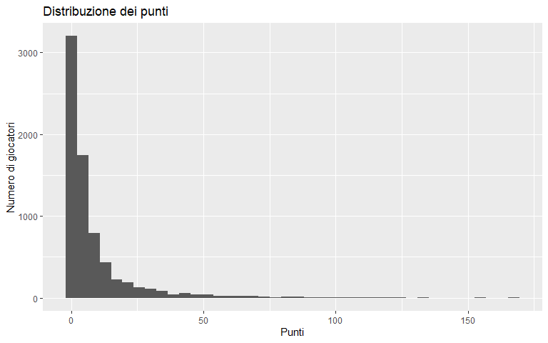

```r
ggplot(points, aes(x = Points)) +
  geom_histogram(bins = 40) +
  labs(
    title = "Distribuzione dei punti",
    x = "Punti",
    y = "Numero di giocatori"
  )
```

## Elo somma zero e Funzione Elo

calcolo intanto la funzione per calcolare Elo

```r
compute_elo = function(data, zeta = 400, kappa = 25) {

  players = unique(c(data$White, data$Black))
  ratings = rep(0, length(players))

  white_index = match(data$White, players)
  black_index = match(data$Black, players)

  for (game in seq_len(nrow(data))) {

    i = white_index[game]
    j = black_index[game]

    expected = 1 / (
      1 + 10 ^ ((ratings[j] - ratings[i]) / zeta)
    )

    change = kappa * (data$Score[game] - expected)

    ratings[i] = ratings[i] + change
    ratings[j] = ratings[j] - change
  }

  total = tibble(
    Player = players,
    Elo = ratings
  ) |>
    arrange(desc(Elo))

  return(total)
}
```

se sommo tutti gli elo, ottengo un valore prossimo allo zero. (probabilmente dovuto a qualche approssimazione) però possiamo confermare che effettivamente è un gioco a somma zero.

```r
elo = compute_elo(data)

sum(elo$Elo)
```

```
## [1] 7.638334e-13
```

Disegnando l’istogramma dei punteggi, possiamo notare come la distribuzione sia leggermente assimetrica. Ci sono più giocatori con Elo <= 0 rispetto a quelli con Elo elevato. Questo può significare la presenza di molti giocatori scarsi / mediocri e pochi giocatori bravissimi. è diversa dalla distribuzione dei punti, perchè qui giocando si può perdere Elo mentre nel grafico di prima, uno giocatore poteva solamente aumentare il proprio punteggio, giocando il più possibile.

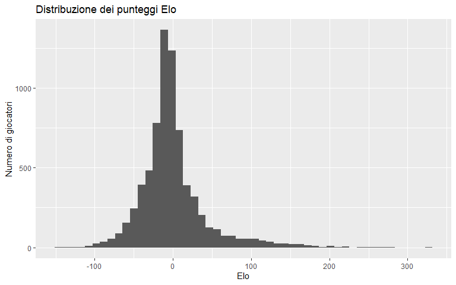

```r
ggplot(elo, aes(x = Elo)) +
  geom_histogram(bins = 50) +
  labs(
    title = "Distribuzione dei punteggi Elo",
    x = "Elo",
    y = "Numero di giocatori"
  )
```

## Correlazione tra Elo e Punti

Guardando lo scatterplot tra Punti e Elo Sembra che le due variabili siano correlate. A punteggi elevati corrispondono alti Elo

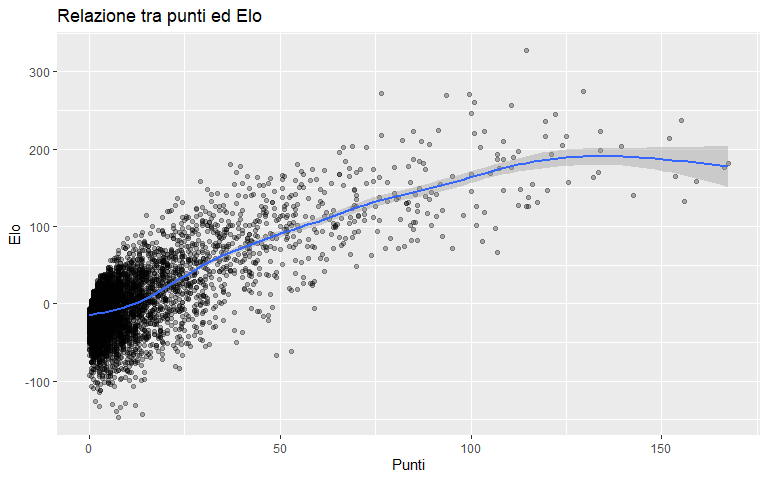

```r
ratings = points |>
  full_join(elo, join_by(Player))

ggplot(ratings, aes(x = Points, y = Elo)) +
  geom_point(alpha = 0.3) +
  labs(
    title = "Relazione tra punti ed Elo",
    x = "Punti",
    y = "Elo"
  )+
  geom_smooth()
```

C’è solo un giocatore che sia contemporaneamente nella top 10 per Elo e per Punti, ed è il giocatore 64

```r
# Seleziona i primi 10 giocatori per ciascuna classifica.
top_points = ratings |>
  slice_max(Points, n = 10, with_ties = FALSE)

top_elo = ratings |>
  slice_max(Elo, n = 10, with_ties = FALSE)

# Trova i giocatori presenti in entrambe.
common_players = intersect(
  top_points$Player,
  top_elo$Player
)

common_players
```

```
## [1] 64
```

## Il numero di partite giocate influenza il punteggio?

Il numero di partite giocate, sembrerebbe influire il numero punti. Questo però è banale, dal momento che i giocatori non possono perdere punti giocando, ma ad ogni partita possono ottenere +0, +0.5 o +1 punti. Quindi c’è un grosso incentivo nel giocare il più possibile.

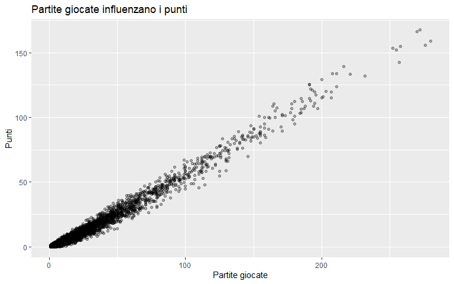

```r
data2 = data |>
  count(White) |>
  full_join(
    data |> count(Black),
    join_by(White == Black)
  ) |>
  mutate(
    Games = replace_na(n.x, 0) + replace_na(n.y, 0)
  ) |>
  select(Player = White, Games) |>
  full_join(ratings, join_by(Player)) |>
  arrange(desc(Elo))

ggplot(data2, aes(x = Games, y = Points)) +
  geom_point(alpha = 0.3) +
  labs(
    title ="Partite giocate influenzano i punti",
    x = "Partite giocate",
    y = "Punti"
  )
```

Dal grafico direi che chi ha giocato più partite tende ad avere un Elo più alto, ma il numero di partite non basta a determinare il rating.

- Con poche partite, molti giocatori hanno un Elo vicino a zero. Perché tutti partono da zero e hanno avuto poche occasioni per allontanarsene.

-La curva blu cresce e poi si appiattisce, indicativamente oltre le 200 partite. In quella zona, però, ci sono pochi giocatori: non interpreterei la lieve discesa finale come prova che giocare troppo faccia diminuire l’Elo.

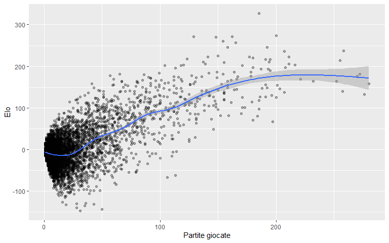

```r
ggplot(data2 , aes(x = Games, y = Elo)) +
  geom_point(alpha = 0.3) +
  labs(
    x = "Partite giocate",
    y = "Elo"
  )+
  geom_smooth()
```